# Guide CR

Paloma

8-7-2019

The intention of this document is to present how to calculate the **controlled direct effect** and the **total effect** when competing events are present using the estimands proposed in the following paper [by Young et al](https://arxiv.org/abs/1806.06136).

The example dataset is **Byar & Greene prostate cancer data**, downloaded from the following [website](http://biostat.mc.vanderbilt.edu/wiki/Main/DataSets).

## Data setup

To get the same dataset required in the paper we followed the next steps:

```r
data <- import("../00_rawdata/prostate_data.RData")


data <- data %>%
  filter(rx == 1 | rx == 4) %>%
  mutate(
    rx = ifelse(rx == 4, 1, 0),
    death = case_when(status == 1 ~ 0,
                      status == 2 ~ 1,
                      TRUE ~ 2),
    death_pr = ifelse(death == 1, 1, 0),
    death_other = ifelse(death == 2, 1, 0),
    cens = ifelse(status == 1, 1, 0),
    age_f = case_when(age <= 60 ~ 1,
                      age > 60 & age < 75 ~ 2,
                      age >= 75 ~ 3),
    age_f = as.factor(age_f),
    hg_f = ifelse(hg < 12, 1, 0),
    hg_f = as.factor(hg_f),
    pf_f = ifelse(pf == 1, 0, 1),
    pf_f = as.factor(pf_f)
  ) %>%
  rename(
    id = patno,
    max = dtime,
    exposure = rx,
    outcome = death_pr,
    competing = death_other
  )
```

Now that we have the data set, we will proceed by estimating the different estimands.

## Direct effect

### Direct effect IPW

1. Call functions:

```r
source("../01_functions/36_direct_ipw_prost.R")
source("../01_functions/36_bootsamples.R")
source("../01_functions/36_wrapper.R")
```

2. Define the arguments for the estimand function:

We need to create a vector with the parameters we are interested in each model.

- Censoring model: `c_model`
- Competing event model: `d_model`
- Event model: `y_model`
- *Exposure model: Since the example uses data from an RCT they do not create weights for the exposure, I will need to create them when I implement the models in observational data.*

We will also create an object with the max time of follow up.

```r
y_model <- c("exposure*(time + I(time^2) + I(time^3))")
d_model <- c("exposure", "time", "I(time^2)", "pf_f", "age_f", "hg_f", "hx")
c_model <- c("exposure", "pf_f", "age_f", "hx")
```

3. Use the function `direct_ipw_pr_helper`, which requeries the following arguments: data, surv_model (estimand function), factors_outcome (parameters for the outcome), factors_cens (parameters for the censoring), factors_cr (parameters for the competing event), rows (the administrative censoring time, by default uses the max time of follow up but can be changed to an earlier time of censoring), seed, n (number of bootstraps).

To understand and adapt the function of the estimand please go to the following [page](https://github.com/palolili23/comp_risk/blob/master/01_functions/36_direct_ipw_prost.R)

```r
results_ipw <- direct_ipw_pr_helper(
  data,
  surv_model = direct_ipw_pr,
  factors_outcome = y_model,
  factors_cens = c_model,
  factors_cr = d_model,
  rows = 60,
  seed = 123,
  n = 100
)
```

4. We use the output obtained to estimate the following estimands, for all timepoints:
- $Pr[Y_{k+1}^{a=0, c=0, d=0} = 1]$
- $Pr[Y_{k+1}^{a=1, c=0, d=0} = 1]$
- $Pr[Y_{k+1}^{a=1, c=0, d=0} = 1] - Pr[Y_{k+1}^{a=0, c=0, d=0} = 1]$
- $\frac{Pr[Y_{k+1}^{a=1, c=0, d=0} = 1]}{Pr[Y_{k+1}^{a=0, c=0, d=0} = 1]}$

```r
effect_measures_ipw_cr <- risk_diff_ratio(results_ipw)

effect_measures_ipw_cr %>%
  head() %>%
  kable() %>%
  kable_styling(
    bootstrap_options = c("hover", "condensed", "responsive"),
    full_width = F,
    font_size = 14)
```

| Time | Risk Ya=1 | Risk Ya=0 | Risk Rifference | RD CI95% | Risk Ratio | RR CI95% |
| --- | --- | --- | --- | --- | --- | --- |
| 0 | 0.006 | 0.008 | -0.003 | -0.013, 0.007 | 0.660 | 0.058, 2.199 |
| 1 | 0.011 | 0.016 | -0.005 | -0.023, 0.013 | 0.680 | 0.073, 2.107 |
| 2 | 0.016 | 0.023 | -0.007 | -0.03, 0.018 | 0.698 | 0.087, 2.041 |
| 3 | 0.022 | 0.030 | -0.009 | -0.036, 0.022 | 0.713 | 0.103, 1.993 |
| 4 | 0.027 | 0.037 | -0.010 | -0.041, 0.025 | 0.727 | 0.121, 1.961 |
| 5 | 0.032 | 0.043 | -0.011 | -0.047, 0.026 | 0.740 | 0.14, 1.881 |

For time point 60

```r
effect_measures_ipw_cr %>%
  filter(Time ==  59) %>%
  kable() %>%
  kable_styling(
    bootstrap_options = c("hover", "condensed", "responsive"),
    full_width = F,
    font_size = 14)
```

| Time | Risk Ya=1 | Risk Ya=0 | Risk Rifference | RD CI95% | Risk Ratio | RR CI95% |
| --- | --- | --- | --- | --- | --- | --- |
| 59 | 0.362 | 0.375 | -0.014 | -0.175, 0.173 | 0.964 | 0.572, 1.552 |

5. Plot the cumulative incidence over time and the survival probability over time.

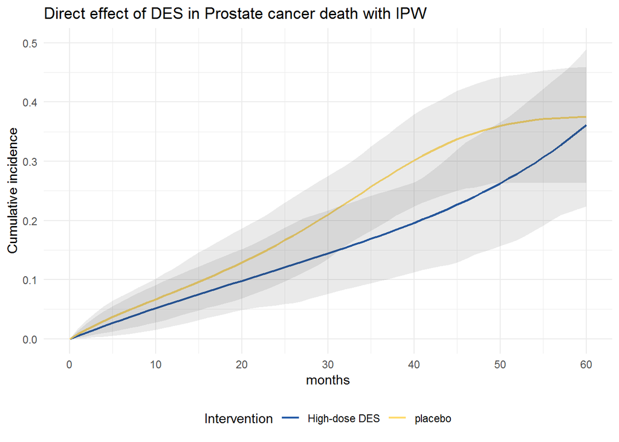

```r
cif_curves(
  results_ipw,
  control = "placebo",
  intervention = "High-dose DES",
  title = "Direct effect of DES in Prostate cancer death with IPW",
  xaxis = "months",
  limit_end = 60,
  breaks = 10,
  max_cif = 0.5
)
```

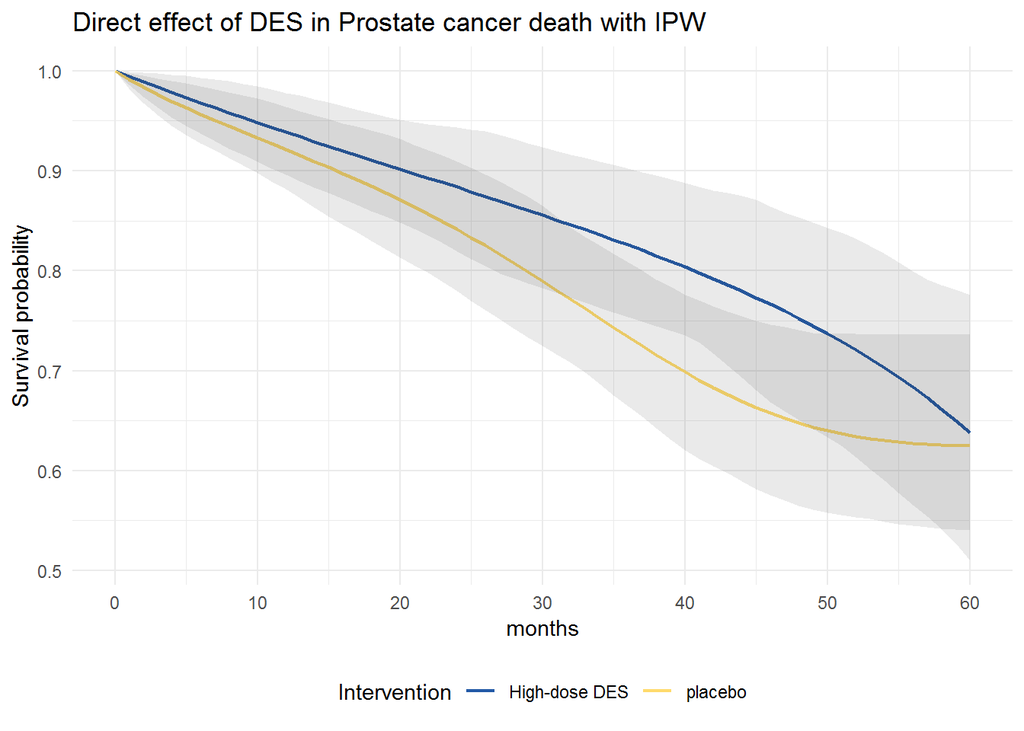

```r
surv_curves(
  results_ipw,
  control = "placebo",
  intervention = "High-dose DES",
  title = "Direct effect of DES in Prostate cancer death with IPW",
  xaxis = "months",
  limit_end = 60,
  breaks = 10,
  max_cif = 0.5
)
```

### Direct effect via G-formula

1. Call functions:

```r
source("../01_functions/35_direct_gf_prost.R")
source("../01_functions/35_bootsamples.R")
source("../01_functions/35_wrapper.R")
```

2. Define the arguments for the estimand function: A vector with the variables for the outcome model and define the max. timepoints.
- Event model: `y_model`

```r
y_model <- c("exposure*(time + I(time^2) + I(time^3))", "pf_f", "age_f", "hg_f", "hx")
```

3. Use the `direct_gf_pr_helper` to get the estimates from the observed dataset and the bootstrap sample.

To understand and adapt the function of the estimand please go to the following [page](https://github.com/palolili23/comp_risk/blob/master/01_functions/35_direct_gf_prost.R)

```r
output_dir_gf <- direct_gf_pr_helper(
  data,
  factors_outcome = y_model,
  n = 100,
  seed = 123,
  rows = 60,
  surv_model = direct_gf_pr
)
```

4. To get the results with confidence intervals, we will only present at time 60.

```r
effect_measures_dir_gf <- risk_diff_ratio(output_dir_gf)

effect_measures_dir_gf %>%
  filter(Time ==  59) %>%
  kable() %>%
  kable_styling(
    bootstrap_options = c("hover", "condensed", "responsive"),
    full_width = F,
    font_size = 14
  )
```

| Time | Risk Ya=1 | Risk Ya=0 | Risk Rifference | RD CI95% | Risk Ratio | RR CI95% |
| --- | --- | --- | --- | --- | --- | --- |
| 59 | 0.355 | 0.377 | -0.023 | -0.188, 0.139 | 0.94 | 0.567, 1.411 |

5. Cumulative incidence graph:

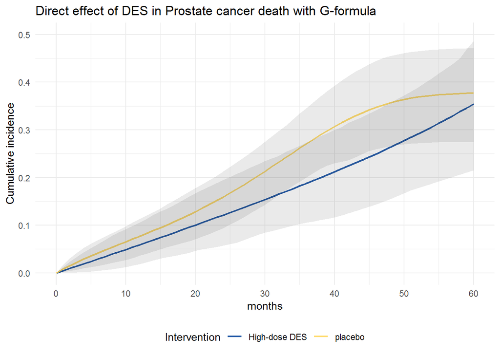

```r
cif_curves(
  output_dir_gf,
  control = "placebo",
  intervention = "High-dose DES",
  title = "Direct effect of DES in Prostate cancer death with G-formula",
  xaxis = "months",
  limit_end = 60,
  breaks = 10,
  max_cif = 0.5
)
```

We will omit the survival curves graph, but can be coded as in the previous example.

## Total effect

### Total effec IPWsh

1. Call functions:

```r
source("../01_functions/38_total_ipwsh_prost.R")
source("../01_functions/38_bootsamples.R")
source("../01_functions/38_wrapper.R")
```

2. Define required models:

```r
y_model <- c("exposure*(time + I(time^2) + I(time^3))")
c_model <- c("exposure", "pf_f", "age_f", "hx")
```

3. Use the `total_ipwsh_helper` to get the estimates from the observed dataset and the bootstrap sample.

```r
results_ipwsh <- total_ipwsh_helper(
  data,
  factors_outcome = y_model,
  factors_cens = c_model,
  rows = 60,
  n = 100,
  seed = 123
)
```

4. Estimate the point estimates and confidence intervals.

Observe that the estimands for the total effects are different that for the direct effect.

- $Pr[Y_{k+1}^{a=0, c=0} = 1]$
- $Pr[Y_{k+1}^{a=1, c=0} = 1]$
- $Pr[Y_{k+1}^{a=1, c=0} = 1] - Pr[Y_{k+1}^{a=0, c=0} = 1]$
- $\frac{Pr[Y_{k+1}^{a=1, c=0} = 1]}{Pr[Y_{k+1}^{a=0, c=0} = 1]}$

```r
effect_measures_ipwsh <- risk_diff_ratio(results_ipwsh)

effect_measures_ipwsh %>%
  filter(Time == 59) %>%
  kable() %>%
  kable_styling(
    bootstrap_options = c("hover", "condensed", "responsive"),
    full_width = F,
    font_size = 14
  )
```

| Time | Risk Ya=1 | Risk Ya=0 | Risk Rifference | RD CI95% | Risk Ratio | RR CI95% |
| --- | --- | --- | --- | --- | --- | --- |
| 59 | 0.215 | 0.276 | -0.061 | -0.168, 0.048 | 0.779 | 0.46, 1.222 |

5. Cumulative incidence curves:

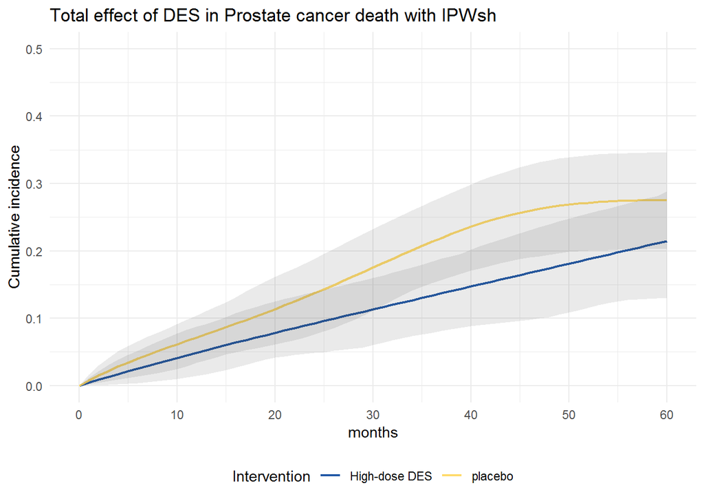

```r
cif_curves(
  results_ipwsh,
  control = "placebo",
  intervention = "High-dose DES",
  title = "Total effect of DES in Prostate cancer death with IPWsh",
  xaxis = "months",
  limit_end = 60,
  breaks = 10,
  max_cif = 0.5
)
```

### Total effect IPWcs

1. Call functions:

```r
source("../01_functions/39_total_ipwcs_prost.R")
source("../01_functions/39_bootsamples.R")
source("../01_functions/39_wrapper.R")
```

2. Define required models:

```r
y_model <- c("exposure*(time + I(time^2) + I(time^3))")
c_model <- c("exposure", "pf_f", "age_f", "hx")
d_model <- c("exposure", "time", "I(time^2)")
```

3. Use the `total_ipwcs_helper` to get the estimates from the observed dataset and the bootstrap samples. To understand and adapt the function of the estimand please go to the following [page](https://github.com/palolili23/comp_risk/blob/master/01_functions/39_total_ipwcs_prost.R)

```r
results_ipwcs <- total_ipwcs_helper(
  data,
  factors_outcome = y_model,
  factors_cens = c_model,
  factors_cr = d_model,
  rows = 60,
  n = 100,
  seed = 123
)
```

4. Estimate the point estimates and confidence intervals.

```r
effect_measures_totalgf <- risk_diff_ratio(results_ipwcs)

effect_measures_totalgf %>%
  filter(Time == 59) %>%
  kable() %>%
  kable_styling(
    bootstrap_options = c("hover", "condensed", "responsive"),
    full_width = F,
    font_size = 14
  )
```

| Time | Risk Ya=1 | Risk Ya=0 | Risk Rifference | RD CI95% | Risk Ratio | RR CI95% |
| --- | --- | --- | --- | --- | --- | --- |
| 59 | 0.216 | 0.275 | -0.059 | -0.167, 0.05 | 0.785 | 0.464, 1.226 |

5. Cumulative incidence curves:

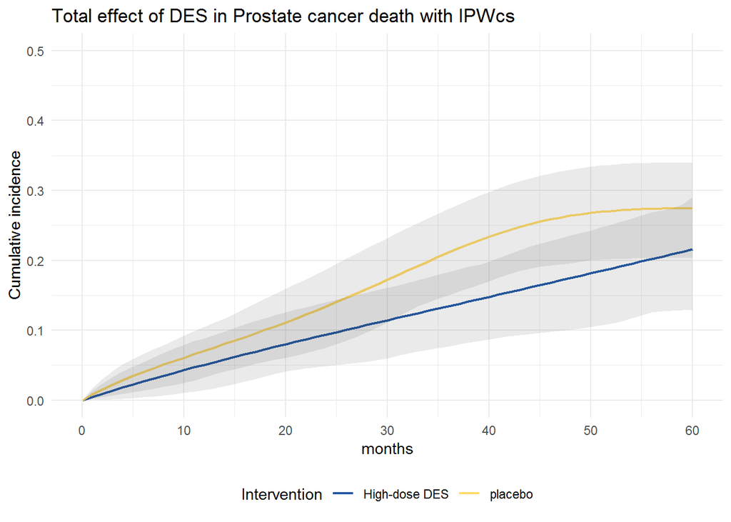

```r
cif_curves(
  results_ipwcs,
  control = "placebo",
  intervention = "High-dose DES",
  title = "Total effect of DES in Prostate cancer death with IPWcs",
  xaxis = "months",
  limit_end = 60,
  breaks = 10,
  max_cif = 0.5
)
```

### Total effect G-formula

1. Call functions:

```r
source("../01_functions/37_total_gf_prost.R")
source("../01_functions/37_bootsamples.R")
source("../01_functions/37_wrapper.R")
```

2. Define required models:

```r
y_model <- c("exposure*(time + I(time^2) + I(time^3))", "pf_f", "age_f", "hg_f", "hx")
d_model <- c("exposure", "time", "I(time^2)", "pf_f", "age_f", "hg_f", "hx")
```

3. Use the `total_gf_helper` to get the estimates from the observed dataset and the bootstrap samples. To understand and adapt the function of the estimand please go to the following [page](https://github.com/palolili23/comp_risk/blob/master/01_functions/37_total_gf_prost.R)

```r
results_totalgf <-
  total_gf_helper(
    data,
    factors_outcome = y_model,
    factors_cr = d_model,
    rows = 60,
    n = 100,
    seed = 123
  )
```

4. Estimate the point estimates and confidence intervals.

```r
effect_measures_totalgf <- risk_diff_ratio(results_totalgf)

effect_measures_totalgf %>%
  filter(Time == 59) %>%
  kable() %>%
  kable_styling(
    bootstrap_options = c("hover", "condensed", "responsive"),
    full_width = F,
    font_size = 14
  )
```

| Time | Risk Ya=1 | Risk Ya=0 | Risk Rifference | RD CI95% | Risk Ratio | RR CI95% |
| --- | --- | --- | --- | --- | --- | --- |
| 59 | 0.214 | 0.275 | -0.06 | -0.168, 0.046 | 0.78 | 0.464, 1.191 |

5. Cumulative incidence curves:

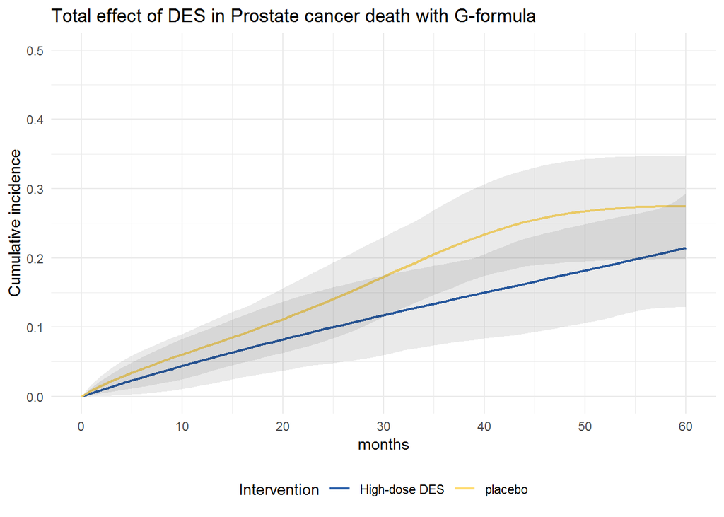

```r
cif_curves(
  results_totalgf,
  control = "placebo",
  intervention = "High-dose DES",
  title = "Total effect of DES in Prostate cancer death with G-formula",
  xaxis = "months",
  limit_end = 60,
  breaks = 10,
  max_cif = 0.5
)
```